# R中的魔方矩阵

MatrixSpk

2011-08-29

某个朋友去证券公司笔试），题目中竟然有一道要求用C语言完成魔方矩阵的输出。如果之前没有做过相关练习，骤然间写出代码可是不容易的事情。

今天下午查了一下R中的魔方矩阵，发现里面已经有一个magic包可以完成魔方矩阵的输出。R真有点无所不包的气势。

# 魔方矩阵：原理、应用与可视化实现

## 一、数学原理

魔方矩阵（Magic Square）又称幻方，是$n \times n$的方阵，满足以下特性： 1. ‌**等和定律**‌：每行、每列及两条主对角线的元素和相等，称为魔方常数$M = \frac{n(n^2+1)}{2}$； 2. ‌**元素排列**‌：包含$1$到$n^2$的连续自然数； 3. ‌**构造规律**‌：奇数阶常用Siamese方法（楼梯法），偶数阶采用LUX或边界填充策略。

以3阶魔方为例：

$$\begin{bmatrix}
8 & 1 & 6 \\
3 & 5 & 7 \\
4 & 9 & 2 \\
\end{bmatrix}$$

其行、列、对角线之和均为$15$。

## 二、核心价值

### 1. 科学研究维度

- ‌**数论验证**‌：魔方常数与矩阵阶数的数学关系为代数理论提供验证案例
- ‌**组合优化**‌：启发旅行商问题(TSP)、排班系统等组合优化算法设计

### 2. 文化应用场景

- ‌**密码原型**‌：古代战争曾用魔方矩阵加密军事情报
- ‌**艺术设计**‌：印度泰姬陵地砖、敦煌壁画均包含幻方图案

## 三、R语言实现

### 1. 构造魔方矩阵

```r
# 安装必要包
if (!require("magic")) install.packages("magic")
library(magic)

# 生成5阶魔方矩阵
magic_matrix <- magic(5)
print(magic_matrix)
```

```
##      [,1] [,2] [,3] [,4] [,5]
## [1,]    9    2   25   18   11
## [2,]    3   21   19   12   10
## [3,]   22   20   13    6    4
## [4,]   16   14    7    5   23
## [5,]   15    8    1   24   17
```

### 2. 可视化

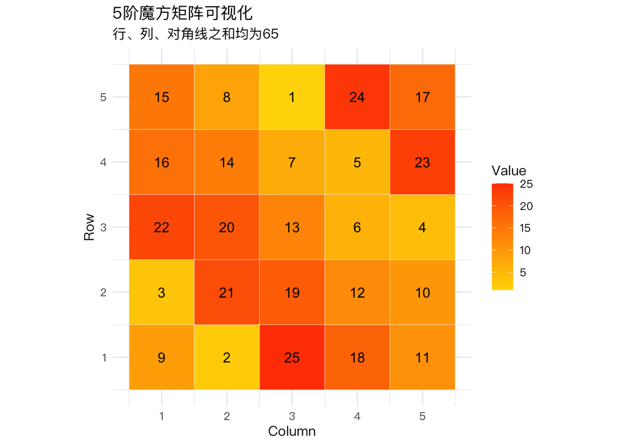

```r
library(ggplot2)
library(reshape2)

# 数据重塑
melted_matrix <- melt(magic_matrix)
colnames(melted_matrix) <- c("Row", "Column", "Value")

# 绘制热力图
ggplot(melted_matrix, aes(x = Column, y = Row, fill = Value)) +
  geom_tile(color = "white") +
  scale_fill_gradient(low = "#FFD700", high = "#FF4500") +
  geom_text(aes(label = Value), color = "black", size = 4) +
  theme_minimal(base_family="PingFang SC") +
  labs(title = "5阶魔方矩阵可视化",
       subtitle = "行、列、对角线之和均为65") +
  coord_fixed()
```

还可以写一段更简单的代码：

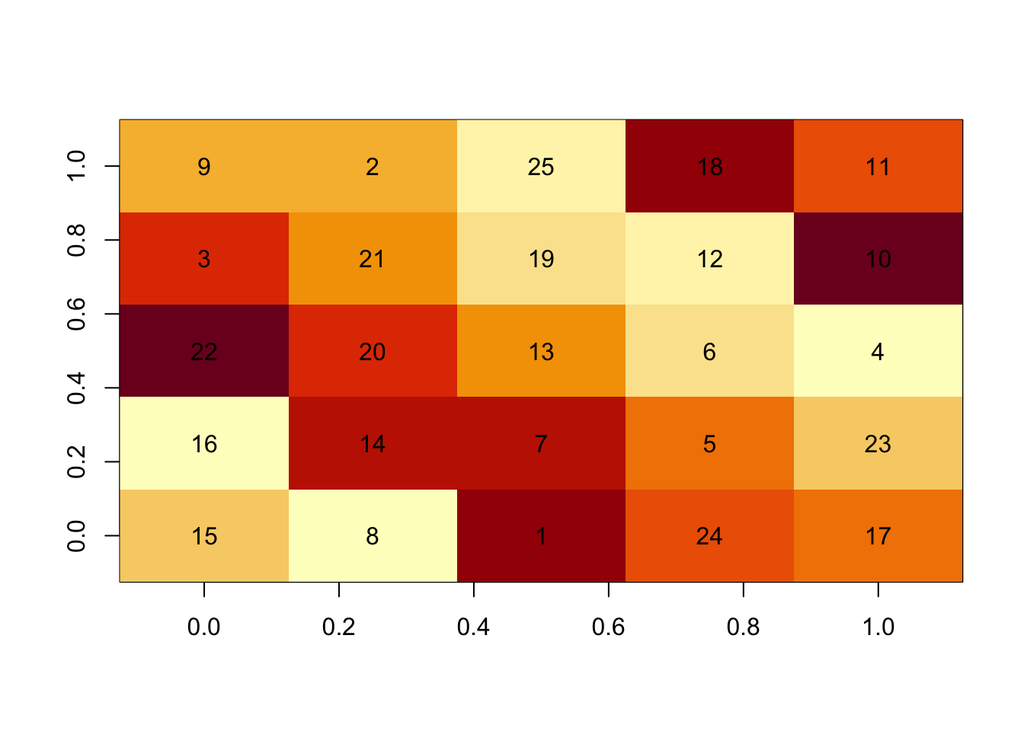

```r
# 安装包，如果为安装
# install.packages("magic")
library(magic)
# 定义魔方矩阵函数magic.image()
magic.image <- function(n,...){
    # 生成n阶魔方矩阵
    m<- magic(n)
    # 生成魔方矩阵热图
    image(m)
    # 添加数字标签
    for(j in 1:n){
        for(i in 1:n){
            text(1/(n-1)*i-1/(n-1),1+1/(n-1)-1/(n-1)*j,m[j,i])
        }
    }
}
# 使用函数
magic.image(5)
```